*Libraries necesaires*

### Création du tableau

Ce tableau correspond à un relevé journalier du nombre de décès de femmes de 80 ans et plus, sur la période des années 1910-1912.

```r
x <- c(0,1,2,3,4,5,6,7,8,9) #Nombres de décès
y <- c(162,267,271,185,111,61,27,8,3,1) #Nombres de jours
donnees <- data.frame(rbind(x,y)) # pour pouvoir travailler sur l'algo EM
tableau <- data.frame(cbind(x,y)) #On choisit d'utiliser la fonction "cbind" au lieu de la fonction "rbind" pour pouvoir directement utiliser la Data Frame pour générer plus facilement des graphiques
```

### 1. Data Viz : Barplots

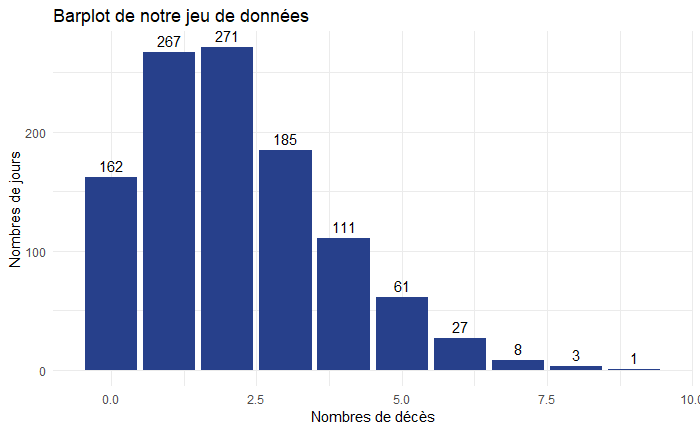

```r
diagramme_batons <- ggplot(tableau)+aes(x=x, y=y)+geom_bar(stat="identity", fill="royalblue4")+theme_minimal()
diagramme_batons+labs(x="Nombres de décès", y="Nombres de jours", title="Barplot de notre jeu de données")+geom_text(aes(label=y), vjust=-0.5, color="black",position = position_dodge(1), size=4)
```

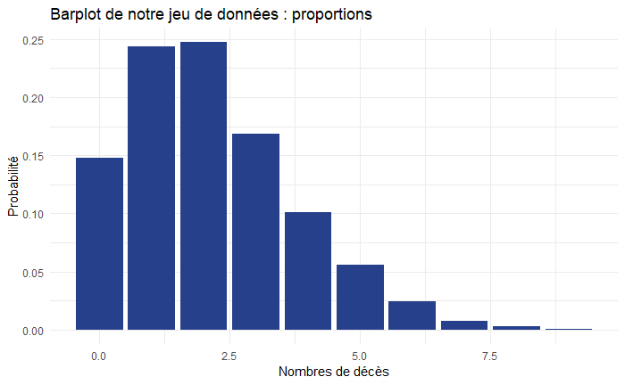

```r
diagramme_prob <-  ggplot(tableau)+aes(x=x, y=y/sum(y))+geom_bar(stat="identity", fill="royalblue4")+theme_minimal()
diagramme_prob+labs(x="Nombres de décès", y="Probabilité", title="Barplot de notre jeu de données : proportions")#+geom_text(aes(label=y/sum(y)), vjust=0, color="black",position = position_dodge(1), size=4)
```

# Modèle 1 :

On commence par modéliser ces données comme un échantillon $i.i.d$ issu d’une variable $X$ suivant une loi de Poisson de paramètre $Î»$ :

$f_{X}(x)=\frac{Î»^{x}}{x!}e^{-Î»}$

### 2. Expression EMV loi de Poisson

Nous allons détailler le calcul de l’expression de l’estimateur de maximum de vraissemblance *(EMV)* dans un modèle de Poisson.

*Rappel :* La fonction $\mathcal{L}_{n} : (x_{1},...,x_{n} ; \theta) \mapsto \mathcal{L}_{n}(x_{1},...,x_{n} ; \theta) = \prod_{i=1}^{n} \mathbb{P}_{\theta}(\{ X_i = x_i \})$ pour des $X_i \hookrightarrow \mathcal{L}(\theta)$ s’appelle *la vraissemblance* de la loi $\mathcal{L}$. La $v.a$ obtenue en appliquant la fonction $(x_{1},...,x_{n} ; \theta) \mapsto Argmax_{\theta} \{ \mathcal{L}_{n}(x_{1},...,x_{n} ; \theta) \}$ appliqué au $n$-échantillon $(X_1,...,X_n)$ s’apelle *l’estimateur au maximum de vraissemblance* du paramètre $\theta$ de la loi discrète $\mathcal{L}$.

Supposons que le tirage d’un $n$-échantillon $(X_1,...,X_n)$ de $v.a$ suivant une loi de Possion $\mathcal{P}(\lambda)$, oÃ¹ $\lambda > 0$ est inconnu, ait produit l’échantillon $x_{1},...,x_{n}$. Ici $\theta = \lambda$, et $\mathbb{P}_{\theta}(\{ X_i = x_i \})= \frac{\theta^{x_i}}{x_i !} e^{-\theta}$ ; la vraissemblance de l’échantillon $x_1,...,x_n$ est donc donnée ici : $\mathcal{L}_{n} : (x_{1},...,x_{n} ; \lambda) = \prod_{i=1}^{n} \frac{\lambda^{x_i}}{x_i !} e^{-\lambda}$ $\mathcal{L}_{n} : (x_{1},...,x_{n} ; \lambda) = e^{-n \lambda} \ \frac{\lambda_{\sum_{i=1}^{n}x_i}}{\prod_{i=1}^{n} x_i !}$,

et donc

$\mathcal{L}_{n} : (x_{1},...,x_{n} ; \lambda) = e^{-n \lambda} \ \frac{\lambda^{s}}{\prod_{i=1}^{n} x_i !}$, oÃ¹ l’on pose $s:= x_1+...+x_n$. Il est plus commode de calculer l’expression *EMV* avec le logarithme $ln$, et comme $ln$ est une fonction croissante il suffit de rechercher le maximum de $\lambda^{*}$ de :

$l_n(x_1,...,x_n;\lambda)=ln(\mathcal{L}_{n} : (x_{1},...,x_{n} ; \lambda)=-n\lambda + s \ ln(\lambda) - \sum_{i=1}^{n} ln(x_i !)$.

Cette fonction est concave et son extremum $\lambda^*$ est donc le zéro de la dérivée $-n+\frac{s}{\lambda}$, c’est à dire $\lambda^* = \frac{s}{n}$.

Nous trouvons donc $\lambda^{MV} := \frac{X_1+...+X_n}{n}$ comme estimateur de $\lambda$ (de plus $\lambda=\mathbb{E}(X_i)$ pour toute $v.a X_i$ suivant une loi de Poisson de paramètre $\lambda$).

### 3. La valeur de l’EMV sur nos données

Nous allons déterminer la valeur de $\lambda^{MV}$ estimée par maximum de vraissemblance sur nos donées.

```r
n=length(donnees) #10
lambdaMV = sum(donnees[1,])/n
print(paste("n = ", n, sep = ""))
```

```
[1] "n = 10"
```

```r
print(paste("lambda MV = ", lambdaMV, sep = ""))
```

```
[1] "lambda MV = 4.5"
```

### 4.1. Barplots pour la loi de Poisson ajustée

```r
#Création d'une troisième ligne correspondant à la loi de Poisson ajustée, qu'on nommera p pour les probabilités
(p <- dpois(x, lambdaMV, log = F))
```

```
 [1] 0.01110900 0.04999048 0.11247859 0.16871788 0.18980762 0.17082686 0.12812014 0.08236295 0.04632916 0.02316458
```

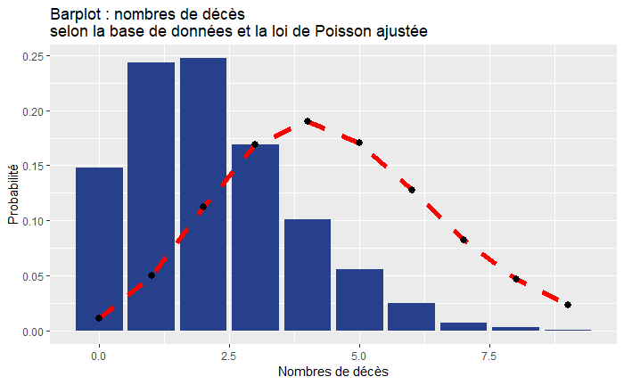

```r
#y/sum(y)
#p
#sum(y/sum(y)) = 1
#sum(p) presque égale à 1
donnees_bis <- data.frame(rbind(donnees, p))
tableau2 <- data.frame(cbind(tableau, p))
diagramme_ajustee <- ggplot(tableau2)+aes(x=x, y=y/sum(y))+geom_bar(stat="identity", fill="royalblue4")+labs(x="Nombres de décès", y="Probabilité", title="Barplot : nombres de décès \nselon la base de données et la loi de Poisson ajustée")
diagramme_ajustee+geom_line(aes(x,p), color="red", size=2,linetype = "dashed")+geom_point(aes(x,p), size=2.5)
```

# Modèle 2 :

### 4.2. Paramètres à estimer

On suppose à présent que la loi du nombre de décès peut être modélisée par une variable $Y$ suivant un mélange de deux lois de Poisson (présence d’un effet saisonnier par exemple).

$Y \sim \sum_{k=1}^{2} \pi_k \mathcal{P}(\lambda_k)$

Ajuster un modèle consiste à estimer les paramètres de celui-ci à l’aide des observations. Les paramètres de ce modèle qui sont à estimer sont : les proportions $\pi_k$ et les paramètes des distributions $\lambda_k$.

### 5. Algorythme EM.

Rappelons le principe de l’algorithme EM pour l’ajustement d’un modèle à deux composantes. EN particulier, nous allons détailler les étapes E et M dans le cas d’un mélange de lois de Poisson.

Premièrement, précissons ce qu’est un mélange de lois de Poisson.

On suppose que les individus sont issus de $K$ groupes ou *populations* (avec $K$ fixé : ici 2). Les réalisations $x_1,...,x_n$ sont supposées êtres des réalisations indépendantes de $v.a$ : $X_1,...,X_n$. POur tout $i \in 1,...,n$ la distribution (loi) de la $v.a$ $X_i$ dépend du groupe auquel $i$ appartient. On commence par introduire la $v.a$ $Z_i$ pour caractériser l’appartenance de l’individu $i$ à un groupe de manière suivante :

$Z_i = (Z_{i1},...,Z_{iK})$ est un *vecteur aléatoire* tel que :

$Z_{ik} = \left\{\begin{array}{rcr} 1 & si \ l'individu \ i \ appartient \ à \ la \ population \ k \\ 0 & sinon \\ \end{array} \right.$

Chaque variable binaire $Z_ik$ suit une loi de Bernouilli de paramètre $\pi_k = \mathbb{P}(Z_{ik}=1)$. $\pi_k$ est la probabilité *a priori* (car elles ne dépendent pas des observations) que l’individu $i$ appartiennent à la population $k$, autrement dit : $\pi_k$ est la taille de la population $k$. On dit donc que le vecteur aléatoire $Z_i$ suit une loi multinomiale de paramètres $1$ et $\pi_1,...,\pi_K$ et on note $Z_i \sim \mathcal{M}(1;\pi_1,...,\pi_K)$.

Sachant que l’individu $i$ appartient à la classe $k$, on suppose que $X_i$ suit une certaine loi (ici de Possion) de densité $f_k = f_{X_i | \{ Z_{ik}=1 \}}$, où $f_k$ est la distribution au sein de la population $k$. On se limiteta par aux famille de lois paramétrées, c’est à dire : $f_k(.)=f(.,\theta_k)$, où $\theta_k$ est le vecteur des paramètres dans la population $k$.

De plus, on considère que dans toutes les populations, le type de loi est le même (ici des lois de Poisson),seuls changent les paramètres $\theta_k$ (ici $\lambda_k$).

On peut aussi considérez la loi du couple $(X_i, Z_i)$ (par abus de notation) :

$$f(x_i, z_i)=f(z_i)f(x_i | z_i)=\pi_{z_i}f(x_i,\theta_{z_i})$$
;

oÃ¹ $\pi_{z_i}=\pi_k$ si l’individu $i$ est dans la population $k$, et $\theta_{z_i}$ est le vecteur de paramètres de la population dont provient l’individu $i$ ($\theta_k$ si $i$ est dans la classe $k$).

On a donc :

$$f(x_i)=\sum_{k=1}^{K} \pi_k f(x_i,\theta_k)$$

Ici, dans le cas d’un mélange de lois de Poisson avec $K=2$ (et $k=1,2$) caractérisé par son paramètre de moyenne $\lambda_k$ on a :

$\theta_k = \lambda_k$ et $f_k(x)=\frac{\lambda_{k}^{x}}{x!} e^{-\lambda_k}$ pour $x \in \mathbb{N}$

Et ici, le modèle de mélange de Poisson s’écrit alors :

$X_i \sim \sum_{k=1}^{2} \pi_k \mathcal{P}(\lambda_k)$

Une fois le modèle de mélange possé, on peut efectuer les estimations des paramètre via l’*EMV* :

-> vraissemblance des donnés incomplètes :

$\mathcal{L}(X;\phi)=\prod_{i=1}^{10}f(x_i)=\prod_{i=1}^{10}[\sum_{k=1} \pi_k f(X_i;\lambda_k)]$,

-> d’oÃ¹ la log-vraissemblance des données incomplètes :

$log \mathcal{L}(X;\phi)=\sum_{i=1}^{10}log[\sum_{k=1} \pi_k f(X_i;\lambda_k)]$,

-> on cherche alors (le maximum de la fonction par rapport aux paramètres) :

$$\frac{\partial log \mathcal{L}(X;\phi)}{\partial \phi} = 0$$
.

Mais l’optimasisation d’une telle vraissemblance est difficile, on obtient pas de formule simple et tout cela vient de l’algorithme de a somme. On a donc besoin d’un *algorithme itératif* pour cette optimisation : *l’algoruthme EM* (Expactation-Maximisation). Dans l’étape E on calcule la vraissemblance conditionnelle et dans l’étape M on maximise la vraissemblance conditionnelle.

### Principe :

A l’itération [h], on a une estimation courante des paramètres du modèle $\phi^{[h]}$. L’algorithme se déroule donc en deux étapes comme décrit ci-dessus.

**Etape E** : Calcul de l’espérance de la vraissemblance conditionnellement aux donées : cela revient à prédire les lables individuels, c’est à dire, à calculer les probabilités d’appartenances a *a posteriori* :

$\widehat{\tau}_{ik}^{[h+1]}=\frac{\pi_k^{[h]} f(x_i;\lambda_k^{[h]})}{\sum_{k=1}^{2}\pi_k^{[h]}f(x_i,\lambda_k^{[h]})}$,

**Etape M** : Maximisation de l’espérance conditionnelle de la vraissemblance calculée dans l’étape E par rapport aux paramètres $\phi$ : cela revient à maximiser l’expression en ayant remplacé les $\mathbb{E}_{\phi^{[h]}}[Z_{ik} | X]$ par les valeurs $\widehat{\tau}_{ik}^{[h+1]}$ obtenues à l’étape E. On cherche donc à maximiser en fonction de chaque paramètre :

$\widehat{\phi}^{[h+1]}=arg max_{\phi}[\mathbb{E}_{\phi^{[h]}}(log\mathcal{L}(X,Z;\phi | X)]$.

### 6. Implémentation de l’algorithme EM sous R

```r
algoEM = function(data,nbcomp,epsilon){
  n   = length(data)
  eps = 1
  #initialisation k-means
  km.init = kmeans(data,centers=nbcomp,nstart=30)
  pik     = km.init$size/n
  muk     = as.vector(km.init$centers)
  sigma2k = km.init$withinss/km.init$size

  resM.old = c(pik,muk,sigma2k)
  llik     = sum(log(apply(sapply(1:nbcomp,FUN=function(j) pik[j]*dnorm(data,muk[j],sqrt(sigma2k[j]))),1,sum)))

while (eps>epsilon){
  #Etape E
  num_tauik= sapply(X = 1:2,FUN= function(i){pik[i]*dpois(x=data,muk[i])})
  den_tauik = apply(X = num_tauik,MARGIN=1,sum)
  tauik=t(sapply(X = 1:n,FUN= function(i){num_tauik[i,]/den_tauik[i]}))
  #Etape M
  pik = c()
  for (i in 1:nbcomp){
    pi=(1/nrow(tauik))*sum(tauik[,i])
    pik=c(pik,pi)
  }

  muk=c()
  for (i in 1:nbcomp){
    mu=(sum(tauik[,i])^-1)*sum(tauik[,i]*data)
    muk=c(muk,mu)
  }

  sigma2k=c()
  for (i in 1:nbcomp){
    sigma2=(sum(tauik[,i])^-1)*(sum(tauik[,i]*(data-muk[i])^2))
    sigma2k=c(sigma2k,sigma2)
  }


  #calcul critere d'arret
  eps = sum((c(pik,muk,sigma2k)-resM.old)^2)/sum(resM.old^2)
  resM.old = c(pik,muk,sigma2k)

  #calcul log-vraisemblance
  llik = c(llik,sum(log(apply(sapply(1:nbcomp,FUN=function(j) pik[j]*dnorm(data,muk[j],sqrt(sigma2k[j]))),1,sum))))
  #eps  = (rev(llik)[1]-rev(llik)[2])/abs(rev(llik[2]))
  }
 resEM = list(tauik = tauik, pik = pik, muk = muk, sigma2k = sigma2k, llik = llik)
 return (resEM)
}
#création de la table Deces pour l'utilisation de l'algorithme EM
Table_Deces = c(rep(0,162),rep(1,267),rep(2,271),rep(3,185),rep(4,111),rep(5,61),rep(6,27),rep(7,8),rep(8,3),rep(9,1))
Modele=algoEM(Table_Deces,2,10^-5)
Resultats=list(Pik=Modele$pik,Lambda=Modele$muk) #les réultats des estimateurs pi1 , pi2, lambda1 et lamba2 suite à l'algorithme EM
Resultats #affichage des estimateur
```

```
$Pik
[1] 0.614608 0.385392

$Lambda
[1] 1.602856 3.040557
```

### 7. Barplot du mélange de lois de Poisson

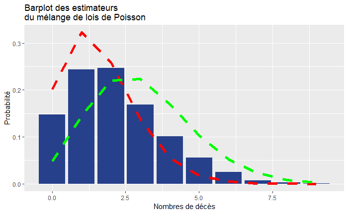

```r
diagramme_modeleMelange <- ggplot(tableau)+aes(x=x, y=y/sum(y))+geom_bar(stat="identity", fill="royalblue4")+labs(x="Nombres de décès", y="Probabilité", title="Barplot des estimateurs \ndu mélange de lois de Poisson")#+geom_line(aes(x,dpois(x, Res$lambdak[1:2], log=F)), color="red", size=2,linetype = "dashed")
p1 <- dpois(x, Resultats$Lambda[1], log = F) #en rouge
p2 <- dpois(x, Resultats$Lambda[2], log=F) #en vert
diagramme_modeleMelange +
  geom_line(aes(x,p1), color="red", size=2,linetype = "dashed") +
  geom_line(aes(x,p2), color="green", size=2,linetype = "dashed")
```